# **Problem Statement**

## **Business Context**

Workplace safety in hazardous environments like construction sites and industrial plants is crucial to prevent accidents and injuries. One of the most important safety measures is ensuring workers wear safety helmets, which protect against head injuries from falling objects and machinery. Non-compliance with helmet regulations increases the risk of serious injuries or fatalities, making effective monitoring essential, especially in large-scale operations where manual oversight is prone to errors and inefficiency.

To overcome these challenges, SafeGuard Corp plans to develop an automated image analysis system capable of detecting whether workers are wearing safety helmets. This system will improve safety enforcement, ensuring compliance and reducing the risk of head injuries. By automating helmet monitoring, SafeGuard aims to enhance efficiency, scalability, and accuracy, ultimately fostering a safer work environment while minimizing human error in safety oversight.

## **Objective**

As a data scientist at SafeGuard Corp, you are tasked with developing an image classification model that classifies images into one of two categories:

- **With Helmet:** Workers wearing safety helmets.
- **Without Helmet:** Workers not wearing safety helmets.

## **Data Description**

The dataset consists of **631 images**, equally divided into two categories:

- **With Helmet:** 311 images showing workers wearing helmets.
- **Without Helmet:** 320 images showing workers not wearing helmets.

**Dataset Characteristics:**

- **Variations in Conditions:** Images include diverse environments such as construction sites, factories, and industrial settings, with variations in lighting, angles, and worker postures to simulate real-world conditions.
- **Worker Activities:** Workers are depicted in different actions such as standing, using tools, or moving, ensuring robust model learning for various scenarios.

# **Installing and Importing the Necessary Libraries**

```python
!pip install tensorflow[and-cuda] numpy==1.25.2 -q
```

[output not shown]

```python
import tensorflow as tf
print("Num GPUs Available:", len(tf.config.list_physical_devices('GPU')))
print(tf.__version__)
```

```
Num GPUs Available: 1
2.19.0
```

**Note:**

- After running the above cell, kindly restart the notebook kernel (for Jupyter Notebook) or runtime (for Google Colab) and run all cells sequentially from the next cell.
- On executing the above line of code, you might see a warning regarding package dependencies. This error message can be ignored as the above code ensures that all necessary libraries and their dependencies are maintained to successfully execute the code in this notebook.

```python
import os
import random
import numpy as np                                                                               # Importing numpy for Matrix Operations
import pandas as pd
import seaborn as sns
import matplotlib.image as mpimg                                                                              # Importing pandas to read CSV files
import matplotlib.pyplot as plt                                                                  # Importting matplotlib for Plotting and visualizing images
import math                                                                                      # Importing math module to perform mathematical operations
import cv2


# Tensorflow modules
import keras
import tensorflow as tf
from tensorflow.keras.preprocessing.image import ImageDataGenerator                              # Importing the ImageDataGenerator for data augmentation
from tensorflow.keras.models import Sequential                                                   # Importing the sequential module to define a sequential model
from tensorflow.keras.layers import Dense,Dropout,Flatten,Conv2D,MaxPooling2D,BatchNormalization # Defining all the layers to build our CNN Model
from tensorflow.keras.optimizers import Adam,SGD                                                 # Importing the optimizers which can be used in our model
from sklearn import preprocessing                                                                # Importing the preprocessing module to preprocess the data
from sklearn.model_selection import train_test_split                                             # Importing train_test_split function to split the data into train and test
from sklearn.metrics import confusion_matrix
from tensorflow.keras.models import Model
from keras.applications.vgg16 import VGG16                                               # Importing confusion_matrix to plot the confusion matrix

# Display images using OpenCV
from google.colab.patches import cv2_imshow

#Imports functions for evaluating the performance of machine learning models
from sklearn.metrics import confusion_matrix, f1_score,accuracy_score, recall_score, precision_score, classification_report
from sklearn.metrics import mean_squared_error as mse                                                 # Importing cv2_imshow from google.patches to display images

# Ignore warnings
import warnings
warnings.filterwarnings('ignore')
```

```python
# Set the seed using keras.utils.set_random_seed. This will set:
# 1) `numpy` seed
# 2) backend random seed
# 3) `python` random seed
tf.keras.utils.set_random_seed(812)
```

# **Data Overview**

## Loading the data

```python
# Loading the image dataset from a NumPy binary file and the corresponding labels from CSV.

from google.colab import drive
drive.mount('/content/drive')

# Path to the .npy file containing the RGB images. Update this path if your file is in a different location.
images_npy_path = '/content/drive/MyDrive/Helmnet/images_proj.npy'

# Load the image data. Each entry in the array should have the shape (height, width, 3).
try:
    X = np.load(images_npy_path)
    print(f"Images loaded successfully with shape: {X.shape}")
except FileNotFoundError as e:
    raise FileNotFoundError(f'Unable to locate {images_npy_path}. Please update the path to your .npy file.') from e

# Load the labels from the provided CSV file.
labels_df = pd.read_csv('/content/drive/MyDrive/Helmnet/Labels_proj.csv')

# The labels are stored in the first column of the CSV.
y = labels_df.iloc[:, 0].values
print(f"Labels loaded successfully with shape: {y.shape} and classes: {np.unique(y)}")

# Check that the number of images matches the number of labels.
assert X.shape[0] == len(y), 'Mismatch between number of images and labels.'
```

```
Images loaded successfully with shape: (631, 200, 200, 3)
Labels loaded successfully with shape: (631,) and classes: [0 1]
```

# **Exploratory Data Analysis**

### Plot random images from each of the classes and print their corresponding labels.

[figure not shown]

```python
# Plot random images from each class along with their labels to get an idea of the dataset.

unique_classes = np.unique(y)
num_classes = len(unique_classes)
samples_per_class = 5  # number of images to display per class

plt.figure(figsize=(num_classes * 3, samples_per_class * 3))

for class_index, cls in enumerate(unique_classes):
    # Extract images belonging to the current class.
    class_images = X[y == cls]
    # Select random indices from the class.
    random_indices = np.random.choice(len(class_images), size=samples_per_class, replace=False)
    for i, img_idx in enumerate(random_indices):
        ax_idx = i * num_classes + class_index + 1
        plt.subplot(samples_per_class, num_classes, ax_idx)
        plt.imshow(class_images[img_idx].astype('uint8'))
        plt.title(f'Class {cls}')
        plt.axis('off')

plt.tight_layout()
plt.show()
```

## Checking for class imbalance

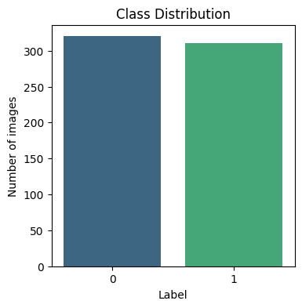

```
Number of images in each class:
0    320
1    311
Name: count, dtype: int64
```

```python
# Check for class imbalance by counting the number of samples in each class.

class_counts = pd.Series(y).value_counts().sort_index()
plt.figure(figsize=(4,4))
sns.barplot(x=class_counts.index.astype(str), y=class_counts.values, palette='viridis')
plt.title('Class Distribution')
plt.xlabel('Label')
plt.ylabel('Number of images')
plt.show()

print('Number of images in each class:')
print(class_counts)
```

# **Data Preprocessing**

## Converting images to grayscale

```
Shape after grayscale conversion: (631, 200, 200, 1)
```

[figure not shown]

```python
# Convert the RGB images to grayscale.
# This reduces the computational complexity for our models while retaining important spatial information.

def rgb_to_gray(images):
    '''
    Convert an array of RGB images to grayscale.
    Args:
        images (numpy.ndarray): Array of shape (n_samples, height, width, 3)
    Returns:
        numpy.ndarray: Array of shape (n_samples, height, width, 1) containing grayscale images
    '''
    gray_images = []
    for img in images:
        # cv2 expects uint8; ensure the input dtype is correct
        gray = cv2.cvtColor(img.astype('uint8'), cv2.COLOR_RGB2GRAY)
        gray_images.append(gray)
    gray_images = np.array(gray_images)
    # Expand dimension to add channel axis
    gray_images = np.expand_dims(gray_images, axis=-1)
    return gray_images

# Apply the conversion
X_gray = rgb_to_gray(X)
print(f"Shape after grayscale conversion: {X_gray.shape}")

# Visualize a few images before and after conversion to grayscale
n_samples_vis = 3
random_indices = np.random.choice(len(X), size=n_samples_vis, replace=False)

plt.figure(figsize=(n_samples_vis * 4, 4))
for i, idx in enumerate(random_indices):
    # Original RGB image
    plt.subplot(2, n_samples_vis, i + 1)
    plt.imshow(X[idx].astype('uint8'))
    plt.title(f'Original (Label {y[idx]})')
    plt.axis('off')

    # Grayscale image
    plt.subplot(2, n_samples_vis, n_samples_vis + i + 1)
    plt.imshow(X_gray[idx].squeeze(), cmap='gray')
    plt.title(f'Grayscale (Label {y[idx]})')
    plt.axis('off')

plt.tight_layout()
plt.show()
```

### Splitting the dataset

```python
# Split the dataset into training, validation, and test sets.
# We first split off a test set, and then split the remaining data into training and validation sets.

test_size = 0.15     # proportion of the data to reserve for the test set
val_size = 0.15      # proportion of the data to reserve for validation from the remaining data

# First split into train_full and test
X_train_full, X_test, y_train_full, y_test = train_test_split(
    X_gray, y, test_size=test_size, stratify=y, random_state=42
)

# Next split the remaining data into train and validation sets
val_ratio = val_size / (1 - test_size)  # adjust validation size relative to the remaining data
X_train, X_val, y_train, y_val = train_test_split(
    X_train_full, y_train_full, test_size=val_ratio, stratify=y_train_full, random_state=42
)

print(f'Training set shape: {X_train.shape}, Labels: {y_train.shape}')
print(f'Validation set shape: {X_val.shape}, Labels: {y_val.shape}')
print(f'Test set shape: {X_test.shape}, Labels: {y_test.shape}')
```

```
Training set shape: (441, 200, 200, 1), Labels: (441,)
Validation set shape: (95, 200, 200, 1), Labels: (95,)
Test set shape: (95, 200, 200, 1), Labels: (95,)
```

### Data Normalization

```python
# Normalize the pixel values of the images to the range [0,1].
# Converting to float32 is important for neural network training stability.

X_train_norm = X_train.astype('float32') / 255.0
X_val_norm   = X_val.astype('float32')   / 255.0
X_test_norm  = X_test.astype('float32')  / 255.0

# Convert labels to float32 for compatibility with TensorFlow
y_train = y_train.astype('float32')
y_val   = y_val.astype('float32')
y_test  = y_test.astype('float32')

print('Data normalization complete.')
```

```
Data normalization complete.
```

# **Model Building**

## Utility Functions

```python
# defining a function to compute different metrics to check performance of a classification model built using statsmodels
def model_performance_classification(model, predictors, target):
    """
    Function to compute different metrics to check classification model performance

    model: classifier
    predictors: independent variables
    target: dependent variable
    """

    # checking which probabilities are greater than threshold
    pred = model.predict(predictors).reshape(-1)>0.5

    target = target.to_numpy().reshape(-1)


    acc = accuracy_score(target, pred)  # to compute Accuracy
    recall = recall_score(target, pred, average='weighted')  # to compute Recall
    precision = precision_score(target, pred, average='weighted')  # to compute Precision
    f1 = f1_score(target, pred, average='weighted')  # to compute F1-score

    # creating a dataframe of metrics
    df_perf = pd.DataFrame({"Accuracy": acc, "Recall": recall, "Precision": precision, "F1 Score": f1,},index=[0],)

    return df_perf
```

```python
def plot_confusion_matrix(model,predictors,target,ml=False):
    """
    Function to plot the confusion matrix

    model: classifier
    predictors: independent variables
    target: dependent variable
    ml: To specify if the model used is an sklearn ML model or not (True means ML model)
    """

    # checking which probabilities are greater than threshold
    pred = model.predict(predictors).reshape(-1)>0.5

    target = target.to_numpy().reshape(-1)

    # Plotting the Confusion Matrix using confusion matrix() function which is also predefined tensorflow module
    confusion_matrix = tf.math.confusion_matrix(target,pred)
    f, ax = plt.subplots(figsize=(10, 8))
    sns.heatmap(
        confusion_matrix,
        annot=True,
        linewidths=.4,
        fmt="d",
        square=True,
        ax=ax
    )
    plt.show()
```

## Model 1: Simple Convolutional Neural Network (CNN)

```
Model: "sequential_2"
```

```
┏━━━━━━━━━━━━━━━━━━━━━━━━━━━━━━━━━┳━━━━━━━━━━━━━━━━━━━━━━━━┳━━━━━━━━━━━━━━━┓
┃ Layer (type)                    ┃ Output Shape           ┃       Param # ┃
┡━━━━━━━━━━━━━━━━━━━━━━━━━━━━━━━━━╇━━━━━━━━━━━━━━━━━━━━━━━━╇━━━━━━━━━━━━━━━┩
│ conv2d_3 (Conv2D)               │ (None, 200, 200, 32)   │           320 │
├─────────────────────────────────┼────────────────────────┼───────────────┤
│ batch_normalization_3           │ (None, 200, 200, 32)   │           128 │
│ (BatchNormalization)            │                        │               │
├─────────────────────────────────┼────────────────────────┼───────────────┤
│ max_pooling2d_3 (MaxPooling2D)  │ (None, 100, 100, 32)   │             0 │
├─────────────────────────────────┼────────────────────────┼───────────────┤
│ conv2d_4 (Conv2D)               │ (None, 100, 100, 64)   │        18,496 │
├─────────────────────────────────┼────────────────────────┼───────────────┤
│ batch_normalization_4           │ (None, 100, 100, 64)   │           256 │
│ (BatchNormalization)            │                        │               │
├─────────────────────────────────┼────────────────────────┼───────────────┤
│ max_pooling2d_4 (MaxPooling2D)  │ (None, 50, 50, 64)     │             0 │
├─────────────────────────────────┼────────────────────────┼───────────────┤
│ conv2d_5 (Conv2D)               │ (None, 50, 50, 128)    │        73,856 │
├─────────────────────────────────┼────────────────────────┼───────────────┤
│ batch_normalization_5           │ (None, 50, 50, 128)    │           512 │
│ (BatchNormalization)            │                        │               │
├─────────────────────────────────┼────────────────────────┼───────────────┤
│ max_pooling2d_5 (MaxPooling2D)  │ (None, 25, 25, 128)    │             0 │
├─────────────────────────────────┼────────────────────────┼───────────────┤
│ flatten_2 (Flatten)             │ (None, 80000)          │             0 │
├─────────────────────────────────┼────────────────────────┼───────────────┤
│ dense_4 (Dense)                 │ (None, 128)            │    10,240,128 │
├─────────────────────────────────┼────────────────────────┼───────────────┤
│ dropout_2 (Dropout)             │ (None, 128)            │             0 │
├─────────────────────────────────┼────────────────────────┼───────────────┤
│ dense_5 (Dense)                 │ (None, 1)              │           129 │
└─────────────────────────────────┴────────────────────────┴───────────────┘
```

```
 Total params: 10,333,825 (39.42 MB)
```

```
 Trainable params: 10,333,377 (39.42 MB)
```

```
 Non-trainable params: 448 (1.75 KB)
```

```
14/14 ━━━━━━━━━━━━━━━━━━━━ 12s 477ms/step - accuracy: 0.9205 - loss: 0.3090 - val_accuracy: 0.5053 - val_loss: 1.1966
14/14 ━━━━━━━━━━━━━━━━━━━━ 2s 109ms/step - accuracy: 0.9913 - loss: 0.0471 - val_accuracy: 0.5053 - val_loss: 3.1592
14/14 ━━━━━━━━━━━━━━━━━━━━ 2s 111ms/step - accuracy: 0.9759 - loss: 0.0576 - val_accuracy: 0.5053 - val_loss: 5.2689
14/14 ━━━━━━━━━━━━━━━━━━━━ 2s 107ms/step - accuracy: 0.9936 - loss: 0.0390 - val_accuracy: 0.5053 - val_loss: 6.7910
14/14 ━━━━━━━━━━━━━━━━━━━━ 2s 106ms/step - accuracy: 0.9927 - loss: 0.0486 - val_accuracy: 0.5053 - val_loss: 7.3912
14/14 ━━━━━━━━━━━━━━━━━━━━ 2s 109ms/step - accuracy: 0.9942 - loss: 0.0307 - val_accuracy: 0.5053 - val_loss: 8.2773
Validation Accuracy (Improved CNN): 0.5053
Test Accuracy (Improved CNN): 0.5053
3/3 ━━━━━━━━━━━━━━━━━━━━ 1s 301ms/step
Classification Report (Improved CNN):
              precision    recall  f1-score   support

         0.0     0.5053    1.0000    0.6713        48
         1.0     0.0000    0.0000    0.0000        47

    accuracy                         0.5053        95
   macro avg     0.2526    0.5000    0.3357        95
weighted avg     0.2553    0.5053    0.3392        95
```

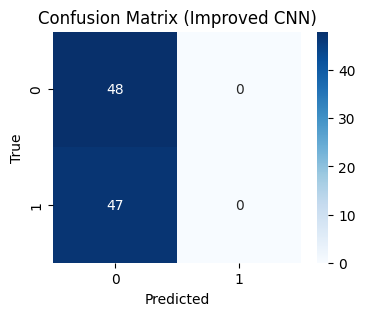

```python
# Build a deeper Convolutional Neural Network (CNN) and train it using data augmentation and early stopping.

# Determine the input shape from the training data
input_shape = X_train_norm.shape[1:]

# Define a deeper CNN architecture to capture more complex patterns
cnn_model = Sequential([
    Conv2D(32, (3, 3), activation='relu', padding='same', input_shape=input_shape),
    BatchNormalization(),
    MaxPooling2D((2, 2)),
    Conv2D(64, (3, 3), activation='relu', padding='same'),
    BatchNormalization(),
    MaxPooling2D((2, 2)),
    Conv2D(128, (3, 3), activation='relu', padding='same'),
    BatchNormalization(),
    MaxPooling2D((2, 2)),
    Flatten(),
    Dense(128, activation='relu'),
    Dropout(0.5),
    Dense(1, activation='sigmoid')  # binary classification
])

# Compile the model with a lower learning rate to stabilize training
cnn_model.compile(
    optimizer=Adam(learning_rate=1e-4),
    loss='binary_crossentropy',
    metrics=['accuracy']
)

# Display the model architecture
cnn_model.summary()

# Set up data augmentation to improve generalization
augmenter = ImageDataGenerator(
    rotation_range=15,
    width_shift_range=0.1,
    height_shift_range=0.1,
    shear_range=0.1,
    zoom_range=0.1,
    horizontal_flip=True
)

# Flow training images in batches of 32 using the data augmentation generator
train_gen = augmenter.flow(X_train_norm, y_train, batch_size=32, shuffle=True)

# Validation generator without augmentation
val_gen = ImageDataGenerator().flow(X_val_norm, y_val, batch_size=32, shuffle=False)

# Use early stopping to prevent overfitting
early_stop = tf.keras.callbacks.EarlyStopping(monitor='val_loss', patience=5, restore_best_weights=True)

# Train the model
epochs = 30
history_cnn = cnn_model.fit(
    train_gen,
    epochs=epochs,
    validation_data=val_gen,
    callbacks=[early_stop],
    verbose=1
)

# Evaluate on the validation and test sets
val_loss_cnn, val_acc_cnn = cnn_model.evaluate(X_val_norm, y_val, verbose=0)
test_loss_cnn, test_acc_cnn = cnn_model.evaluate(X_test_norm, y_test, verbose=0)
print(f'Validation Accuracy (Improved CNN): {val_acc_cnn:.4f}')
print(f'Test Accuracy (Improved CNN): {test_acc_cnn:.4f}')

# Generate predictions on the validation set for detailed metrics
val_preds_probs_cnn = cnn_model.predict(X_val_norm).ravel()
val_preds_cnn = (val_preds_probs_cnn > 0.5).astype('int32')

# Classification report and confusion matrix
print('Classification Report (Improved CNN):')
print(classification_report(y_val, val_preds_cnn, digits=4))

conf_mat_cnn = confusion_matrix(y_val, val_preds_cnn)
plt.figure(figsize=(4,3))
sns.heatmap(conf_mat_cnn, annot=True, fmt='d', cmap='Blues')
plt.title('Confusion Matrix (Improved CNN)')
plt.xlabel('Predicted')
plt.ylabel('True')
plt.show()
```

### Vizualizing the predictions

```
1/1 ━━━━━━━━━━━━━━━━━━━━ 0s 325ms/step
1/1 ━━━━━━━━━━━━━━━━━━━━ 0s 29ms/step
1/1 ━━━━━━━━━━━━━━━━━━━━ 0s 28ms/step
1/1 ━━━━━━━━━━━━━━━━━━━━ 0s 46ms/step
1/1 ━━━━━━━━━━━━━━━━━━━━ 0s 45ms/step
1/1 ━━━━━━━━━━━━━━━━━━━━ 0s 42ms/step
```

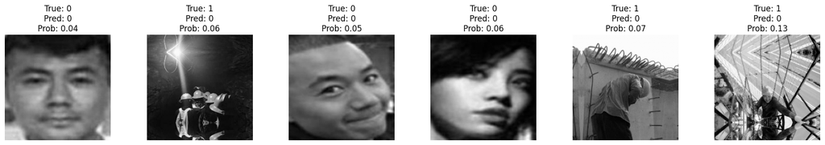

```python
# Visualize a few predictions made by the CNN model on the validation set.

num_examples = 6
indices = np.random.choice(len(X_val_norm), size=num_examples, replace=False)

plt.figure(figsize=(num_examples * 3, 3))
for i, idx in enumerate(indices):
    img = X_val_norm[idx]
    pred_prob = cnn_model.predict(img[None, ...])[0][0]
    pred_label = int(pred_prob > 0.5)
    true_label = int(y_val[idx])

    plt.subplot(1, num_examples, i + 1)
    plt.imshow(img.squeeze(), cmap='gray')
    plt.title(f"True: {true_label}\nPred: {pred_label}\nProb: {pred_prob:.2f}")
    plt.axis('off')

plt.tight_layout()
plt.show()
```

## Model 2: (VGG-16 (Base))

```
Downloading data from https://storage.googleapis.com/tensorflow/keras-applications/vgg16/vgg16_weights_tf_dim_ordering_tf_kernels_notop.h5
58889256/58889256 ━━━━━━━━━━━━━━━━━━━━ 0s 0us/step
```

```
Model: "sequential_1"
```

```
┏━━━━━━━━━━━━━━━━━━━━━━━━━━━━━━━━━┳━━━━━━━━━━━━━━━━━━━━━━━━┳━━━━━━━━━━━━━━━┓
┃ Layer (type)                    ┃ Output Shape           ┃       Param # ┃
┡━━━━━━━━━━━━━━━━━━━━━━━━━━━━━━━━━╇━━━━━━━━━━━━━━━━━━━━━━━━╇━━━━━━━━━━━━━━━┩
│ vgg16 (Functional)              │ (None, 6, 6, 512)      │    14,714,688 │
├─────────────────────────────────┼────────────────────────┼───────────────┤
│ flatten_1 (Flatten)             │ (None, 18432)          │             0 │
├─────────────────────────────────┼────────────────────────┼───────────────┤
│ dense_2 (Dense)                 │ (None, 128)            │     2,359,424 │
├─────────────────────────────────┼────────────────────────┼───────────────┤
│ dropout_1 (Dropout)             │ (None, 128)            │             0 │
├─────────────────────────────────┼────────────────────────┼───────────────┤
│ dense_3 (Dense)                 │ (None, 1)              │           129 │
└─────────────────────────────────┴────────────────────────┴───────────────┘
```

```
 Total params: 17,074,241 (65.13 MB)
```

```
 Trainable params: 2,359,553 (9.00 MB)
```

```
 Non-trainable params: 14,714,688 (56.13 MB)
```

```
14/14 ━━━━━━━━━━━━━━━━━━━━ 45s 3s/step - accuracy: 0.7753 - loss: 0.4660 - val_accuracy: 1.0000 - val_loss: 0.0428
14/14 ━━━━━━━━━━━━━━━━━━━━ 3s 194ms/step - accuracy: 1.0000 - loss: 0.0436 - val_accuracy: 1.0000 - val_loss: 0.0098
14/14 ━━━━━━━━━━━━━━━━━━━━ 3s 195ms/step - accuracy: 0.9974 - loss: 0.0152 - val_accuracy: 1.0000 - val_loss: 0.0051
14/14 ━━━━━━━━━━━━━━━━━━━━ 3s 195ms/step - accuracy: 0.9974 - loss: 0.0079 - val_accuracy: 1.0000 - val_loss: 0.0036
14/14 ━━━━━━━━━━━━━━━━━━━━ 3s 198ms/step - accuracy: 1.0000 - loss: 0.0070 - val_accuracy: 1.0000 - val_loss: 0.0027
14/14 ━━━━━━━━━━━━━━━━━━━━ 3s 196ms/step - accuracy: 1.0000 - loss: 0.0043 - val_accuracy: 1.0000 - val_loss: 0.0022
14/14 ━━━━━━━━━━━━━━━━━━━━ 3s 195ms/step - accuracy: 1.0000 - loss: 0.0060 - val_accuracy: 1.0000 - val_loss: 0.0025
14/14 ━━━━━━━━━━━━━━━━━━━━ 3s 194ms/step - accuracy: 1.0000 - loss: 0.0026 - val_accuracy: 1.0000 - val_loss: 0.0018
14/14 ━━━━━━━━━━━━━━━━━━━━ 3s 213ms/step - accuracy: 1.0000 - loss: 0.0031 - val_accuracy: 1.0000 - val_loss: 0.0014
14/14 ━━━━━━━━━━━━━━━━━━━━ 3s 235ms/step - accuracy: 1.0000 - loss: 0.0026 - val_accuracy: 1.0000 - val_loss: 0.0012
14/14 ━━━━━━━━━━━━━━━━━━━━ 3s 204ms/step - accuracy: 1.0000 - loss: 0.0026 - val_accuracy: 1.0000 - val_loss: 0.0011
14/14 ━━━━━━━━━━━━━━━━━━━━ 3s 216ms/step - accuracy: 1.0000 - loss: 0.0021 - val_accuracy: 1.0000 - val_loss: 0.0010
14/14 ━━━━━━━━━━━━━━━━━━━━ 3s 205ms/step - accuracy: 1.0000 - loss: 0.0021 - val_accuracy: 1.0000 - val_loss: 9.7858e-04
14/14 ━━━━━━━━━━━━━━━━━━━━ 3s 214ms/step - accuracy: 1.0000 - loss: 0.0019 - val_accuracy: 1.0000 - val_loss: 9.2198e-04
14/14 ━━━━━━━━━━━━━━━━━━━━ 3s 219ms/step - accuracy: 1.0000 - loss: 0.0013 - val_accuracy: 1.0000 - val_loss: 8.0085e-04
Validation Accuracy (VGG16 Base): 1.0000
Test Accuracy (VGG16 Base): 1.0000
3/3 ━━━━━━━━━━━━━━━━━━━━ 2s 669ms/step
Classification Report (VGG16 Base):
              precision    recall  f1-score   support

         0.0     1.0000    1.0000    1.0000        48
         1.0     1.0000    1.0000    1.0000        47

    accuracy                         1.0000        95
   macro avg     1.0000    1.0000    1.0000        95
weighted avg     1.0000    1.0000    1.0000        95
```

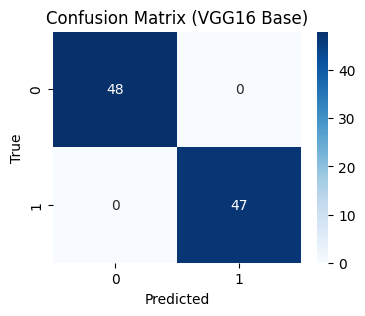

```python
# Build a model using the VGG16 architecture as a fixed feature extractor.
# VGG16 expects 3-channel input, so replicate the grayscale images across three channels.

def to_rgb(images):
    '''
    Replicate single-channel images to three channels.
    Args:
        images (numpy.ndarray): Array of shape (n_samples, height, width, 1)
    Returns:
        numpy.ndarray: Array of shape (n_samples, height, width, 3)
    '''
    return np.repeat(images, 3, axis=-1)

X_train_vgg = to_rgb(X_train_norm)
X_val_vgg   = to_rgb(X_val_norm)
X_test_vgg  = to_rgb(X_test_norm)

# Load the VGG16 base with pre-trained ImageNet weights. Exclude the top layers.
vgg_base = VGG16(weights='imagenet', include_top=False, input_shape=X_train_vgg.shape[1:])

# Freeze the convolutional base so that its weights are not updated during training.
for layer in vgg_base.layers:
    layer.trainable = False

# Build the model
vgg_model = Sequential([
    vgg_base,
    Flatten(),
    Dense(128, activation='relu'),
    Dropout(0.5),
    Dense(1, activation='sigmoid')
])

# Compile the model
vgg_model.compile(
    optimizer=Adam(learning_rate=1e-4),
    loss='binary_crossentropy',
    metrics=['accuracy']
)

# Display the model architecture
vgg_model.summary()

# Train the model
epochs = 15
batch_size = 32
history_vgg = vgg_model.fit(
    X_train_vgg, y_train,
    epochs=epochs,
    batch_size=batch_size,
    validation_data=(X_val_vgg, y_val),
    verbose=1
)

# Evaluate on the validation and test sets
val_loss_vgg, val_acc_vgg = vgg_model.evaluate(X_val_vgg, y_val, verbose=0)
test_loss_vgg, test_acc_vgg = vgg_model.evaluate(X_test_vgg, y_test, verbose=0)
print(f'Validation Accuracy (VGG16 Base): {val_acc_vgg:.4f}')
print(f'Test Accuracy (VGG16 Base): {test_acc_vgg:.4f}')

# Predictions and metrics
val_preds_probs_vgg = vgg_model.predict(X_val_vgg).ravel()
val_preds_vgg = (val_preds_probs_vgg > 0.5).astype('int32')

print('Classification Report (VGG16 Base):')
print(classification_report(y_val, val_preds_vgg, digits=4))

conf_mat_vgg = confusion_matrix(y_val, val_preds_vgg)
plt.figure(figsize=(4,3))
sns.heatmap(conf_mat_vgg, annot=True, fmt='d', cmap='Blues')
plt.title('Confusion Matrix (VGG16 Base)')
plt.xlabel('Predicted')
plt.ylabel('True')
plt.show()
```

### Visualizing the prediction:

```
1/1 ━━━━━━━━━━━━━━━━━━━━ 2s 2s/step
1/1 ━━━━━━━━━━━━━━━━━━━━ 0s 44ms/step
1/1 ━━━━━━━━━━━━━━━━━━━━ 0s 38ms/step
1/1 ━━━━━━━━━━━━━━━━━━━━ 0s 39ms/step
1/1 ━━━━━━━━━━━━━━━━━━━━ 0s 36ms/step
1/1 ━━━━━━━━━━━━━━━━━━━━ 0s 34ms/step
```

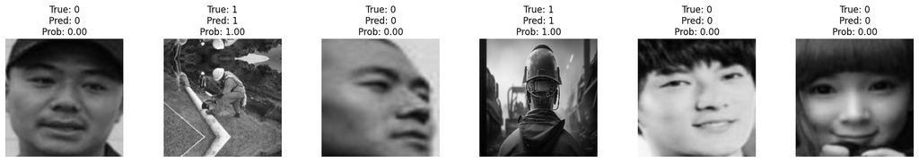

```python
# Visualize a few predictions made by the VGG16 base model on the validation set.

num_examples = 6
indices = np.random.choice(len(X_val_vgg), size=num_examples, replace=False)

plt.figure(figsize=(num_examples * 3, 3))
for i, idx in enumerate(indices):
    img = X_val_vgg[idx]
    pred_prob = vgg_model.predict(img[None, ...])[0][0]
    pred_label = int(pred_prob > 0.5)
    true_label = int(y_val[idx])

    plt.subplot(1, num_examples, i + 1)
    plt.imshow(img.astype('float32'))
    plt.title(f'True: {true_label}\nPred: {pred_label}\nProb: {pred_prob:.2f}')
    plt.axis('off')

plt.tight_layout()
plt.show()
```

## Model 3: (VGG-16 (Base + FFNN))

```
Model: "functional_3"
```

```
┏━━━━━━━━━━━━━━━━━━━━━━━━━━━━━━━━━┳━━━━━━━━━━━━━━━━━━━━━━━━┳━━━━━━━━━━━━━━━┓
┃ Layer (type)                    ┃ Output Shape           ┃       Param # ┃
┡━━━━━━━━━━━━━━━━━━━━━━━━━━━━━━━━━╇━━━━━━━━━━━━━━━━━━━━━━━━╇━━━━━━━━━━━━━━━┩
│ input_layer_5 (InputLayer)      │ (None, 200, 200, 3)    │             0 │
├─────────────────────────────────┼────────────────────────┼───────────────┤
│ vgg16 (Functional)              │ (None, 6, 6, 512)      │    14,714,688 │
├─────────────────────────────────┼────────────────────────┼───────────────┤
│ flatten_3 (Flatten)             │ (None, 18432)          │             0 │
├─────────────────────────────────┼────────────────────────┼───────────────┤
│ dense_6 (Dense)                 │ (None, 256)            │     4,718,848 │
├─────────────────────────────────┼────────────────────────┼───────────────┤
│ dropout_3 (Dropout)             │ (None, 256)            │             0 │
├─────────────────────────────────┼────────────────────────┼───────────────┤
│ dense_7 (Dense)                 │ (None, 128)            │        32,896 │
├─────────────────────────────────┼────────────────────────┼───────────────┤
│ dropout_4 (Dropout)             │ (None, 128)            │             0 │
├─────────────────────────────────┼────────────────────────┼───────────────┤
│ dense_8 (Dense)                 │ (None, 1)              │           129 │
└─────────────────────────────────┴────────────────────────┴───────────────┘
```

```
 Total params: 19,466,561 (74.26 MB)
```

```
 Trainable params: 4,751,873 (18.13 MB)
```

```
 Non-trainable params: 14,714,688 (56.13 MB)
```

```
14/14 ━━━━━━━━━━━━━━━━━━━━ 10s 478ms/step - accuracy: 0.6611 - loss: 0.6562 - val_accuracy: 1.0000 - val_loss: 0.0654
14/14 ━━━━━━━━━━━━━━━━━━━━ 3s 216ms/step - accuracy: 0.9873 - loss: 0.0926 - val_accuracy: 1.0000 - val_loss: 0.0096
14/14 ━━━━━━━━━━━━━━━━━━━━ 3s 230ms/step - accuracy: 0.9991 - loss: 0.0329 - val_accuracy: 1.0000 - val_loss: 0.0028
14/14 ━━━━━━━━━━━━━━━━━━━━ 3s 252ms/step - accuracy: 1.0000 - loss: 0.0186 - val_accuracy: 1.0000 - val_loss: 0.0020
14/14 ━━━━━━━━━━━━━━━━━━━━ 3s 239ms/step - accuracy: 0.9990 - loss: 0.0136 - val_accuracy: 1.0000 - val_loss: 0.0014
14/14 ━━━━━━━━━━━━━━━━━━━━ 3s 219ms/step - accuracy: 1.0000 - loss: 0.0095 - val_accuracy: 1.0000 - val_loss: 0.0012
14/14 ━━━━━━━━━━━━━━━━━━━━ 3s 202ms/step - accuracy: 1.0000 - loss: 0.0100 - val_accuracy: 1.0000 - val_loss: 7.2245e-04
14/14 ━━━━━━━━━━━━━━━━━━━━ 3s 203ms/step - accuracy: 0.9995 - loss: 0.0069 - val_accuracy: 1.0000 - val_loss: 6.1560e-04
14/14 ━━━━━━━━━━━━━━━━━━━━ 3s 201ms/step - accuracy: 1.0000 - loss: 0.0039 - val_accuracy: 1.0000 - val_loss: 6.5131e-04
14/14 ━━━━━━━━━━━━━━━━━━━━ 3s 198ms/step - accuracy: 1.0000 - loss: 0.0068 - val_accuracy: 1.0000 - val_loss: 4.8926e-04
14/14 ━━━━━━━━━━━━━━━━━━━━ 3s 197ms/step - accuracy: 1.0000 - loss: 0.0036 - val_accuracy: 1.0000 - val_loss: 3.1359e-04
14/14 ━━━━━━━━━━━━━━━━━━━━ 3s 196ms/step - accuracy: 1.0000 - loss: 0.0031 - val_accuracy: 1.0000 - val_loss: 2.5757e-04
14/14 ━━━━━━━━━━━━━━━━━━━━ 3s 198ms/step - accuracy: 1.0000 - loss: 0.0048 - val_accuracy: 1.0000 - val_loss: 2.5358e-04
14/14 ━━━━━━━━━━━━━━━━━━━━ 3s 196ms/step - accuracy: 1.0000 - loss: 0.0024 - val_accuracy: 1.0000 - val_loss: 1.5020e-04
14/14 ━━━━━━━━━━━━━━━━━━━━ 3s 194ms/step - accuracy: 1.0000 - loss: 0.0037 - val_accuracy: 1.0000 - val_loss: 1.9947e-04
Validation Accuracy (VGG16 + FFNN): 1.0000
Test Accuracy (VGG16 + FFNN): 1.0000
3/3 ━━━━━━━━━━━━━━━━━━━━ 2s 469ms/step
Classification Report (VGG16 + FFNN):
              precision    recall  f1-score   support

         0.0     1.0000    1.0000    1.0000        48
         1.0     1.0000    1.0000    1.0000        47

    accuracy                         1.0000        95
   macro avg     1.0000    1.0000    1.0000        95
weighted avg     1.0000    1.0000    1.0000        95
```

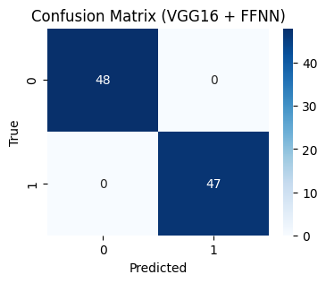

```python
# Build a VGG16-based model with a deeper feed-forward neural network (FFNN) as the classifier.

# Load the base model again to avoid interfering with the previous model.
vgg_base_ffnn = VGG16(weights='imagenet', include_top=False, input_shape=X_train_vgg.shape[1:])

# Freeze the convolutional base layers.
for layer in vgg_base_ffnn.layers:
    layer.trainable = False

# Build the classifier on top of the VGG16 base.
inputs = keras.Input(shape=X_train_vgg.shape[1:])
x = vgg_base_ffnn(inputs, training=False)
x = Flatten()(x)
x = Dense(256, activation='relu')(x)
x = Dropout(0.5)(x)
x = Dense(128, activation='relu')(x)
x = Dropout(0.5)(x)
outputs = Dense(1, activation='sigmoid')(x)

vgg_ffnn_model = keras.Model(inputs, outputs)

# Compile the model
vgg_ffnn_model.compile(
    optimizer=Adam(learning_rate=1e-4),
    loss='binary_crossentropy',
    metrics=['accuracy']
)

# Display the model architecture
vgg_ffnn_model.summary()

# Train the model
epochs = 15
batch_size = 32
history_vgg_ffnn = vgg_ffnn_model.fit(
    X_train_vgg, y_train,
    epochs=epochs,
    batch_size=batch_size,
    validation_data=(X_val_vgg, y_val),
    verbose=1
)

# Evaluate on the validation and test sets
val_loss_ffnn, val_acc_ffnn = vgg_ffnn_model.evaluate(X_val_vgg, y_val, verbose=0)
test_loss_ffnn, test_acc_ffnn = vgg_ffnn_model.evaluate(X_test_vgg, y_test, verbose=0)
print(f'Validation Accuracy (VGG16 + FFNN): {val_acc_ffnn:.4f}')
print(f'Test Accuracy (VGG16 + FFNN): {test_acc_ffnn:.4f}')

# Predictions and metrics
val_preds_probs_ffnn = vgg_ffnn_model.predict(X_val_vgg).ravel()
val_preds_ffnn = (val_preds_probs_ffnn > 0.5).astype('int32')

print('Classification Report (VGG16 + FFNN):')
print(classification_report(y_val, val_preds_ffnn, digits=4))

conf_mat_ffnn = confusion_matrix(y_val, val_preds_ffnn)
plt.figure(figsize=(4,3))
sns.heatmap(conf_mat_ffnn, annot=True, fmt='d', cmap='Blues')
plt.title('Confusion Matrix (VGG16 + FFNN)')
plt.xlabel('Predicted')
plt.ylabel('True')
plt.show()
```

#### Visualizing the predictions

```
1/1 ━━━━━━━━━━━━━━━━━━━━ 1s 534ms/step
1/1 ━━━━━━━━━━━━━━━━━━━━ 0s 33ms/step
1/1 ━━━━━━━━━━━━━━━━━━━━ 0s 33ms/step
1/1 ━━━━━━━━━━━━━━━━━━━━ 0s 34ms/step
1/1 ━━━━━━━━━━━━━━━━━━━━ 0s 34ms/step
1/1 ━━━━━━━━━━━━━━━━━━━━ 0s 32ms/step
```

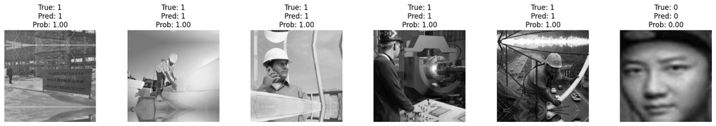

```python
# Visualize a few predictions made by the VGG16 + FFNN model on the validation set.

num_examples = 6
indices = np.random.choice(len(X_val_vgg), size=num_examples, replace=False)

plt.figure(figsize=(num_examples * 3, 3))
for i, idx in enumerate(indices):
    img = X_val_vgg[idx]
    pred_prob = vgg_ffnn_model.predict(img[None, ...])[0][0]
    pred_label = int(pred_prob > 0.5)
    true_label = int(y_val[idx])

    plt.subplot(1, num_examples, i + 1)
    plt.imshow(img.astype('float32'))
    plt.title(f'True: {true_label}\nPred: {pred_label}\nProb: {pred_prob:.2f}')
    plt.axis('off')

plt.tight_layout()
plt.show()
```

## Model 4: (VGG-16 (Base + FFNN + Data Augmentation)

- In most of the real-world case studies, it is challenging to acquire a large number of images and then train CNNs.
- To overcome this problem, one approach we might consider is **Data Augmentation**.
- CNNs have the property of **translational invariance**, which means they can recognise an object even if its appearance shifts translationally in some way. - Taking this attribute into account, we can augment the images using the techniques listed below
  - Horizontal Flip (should be set to True/False)
  - Vertical Flip (should be set to True/False)
  - Height Shift (should be between 0 and 1)
  - Width Shift (should be between 0 and 1)
  - Rotation (should be between 0 and 180)
  - Shear (should be between 0 and 1)
  - Zoom (should be between 0 and 1) etc.

Remember, **data augmentation should not be used in the validation/test data set**.

```
Model: "sequential_3"
```

```
┏━━━━━━━━━━━━━━━━━━━━━━━━━━━━━━━━━┳━━━━━━━━━━━━━━━━━━━━━━━━┳━━━━━━━━━━━━━━━┓
┃ Layer (type)                    ┃ Output Shape           ┃       Param # ┃
┡━━━━━━━━━━━━━━━━━━━━━━━━━━━━━━━━━╇━━━━━━━━━━━━━━━━━━━━━━━━╇━━━━━━━━━━━━━━━┩
│ vgg16 (Functional)              │ (None, 6, 6, 512)      │    14,714,688 │
├─────────────────────────────────┼────────────────────────┼───────────────┤
│ flatten_4 (Flatten)             │ (None, 18432)          │             0 │
├─────────────────────────────────┼────────────────────────┼───────────────┤
│ dense_9 (Dense)                 │ (None, 256)            │     4,718,848 │
├─────────────────────────────────┼────────────────────────┼───────────────┤
│ dropout_5 (Dropout)             │ (None, 256)            │             0 │
├─────────────────────────────────┼────────────────────────┼───────────────┤
│ dense_10 (Dense)                │ (None, 128)            │        32,896 │
├─────────────────────────────────┼────────────────────────┼───────────────┤
│ dropout_6 (Dropout)             │ (None, 128)            │             0 │
├─────────────────────────────────┼────────────────────────┼───────────────┤
│ dense_11 (Dense)                │ (None, 1)              │           129 │
└─────────────────────────────────┴────────────────────────┴───────────────┘
```

```
 Total params: 19,466,561 (74.26 MB)
```

```
 Trainable params: 4,751,873 (18.13 MB)
```

```
 Non-trainable params: 14,714,688 (56.13 MB)
```

```
14/14 ━━━━━━━━━━━━━━━━━━━━ 18s 972ms/step - accuracy: 0.6539 - loss: 0.6130 - val_accuracy: 1.0000 - val_loss: 0.1129
14/14 ━━━━━━━━━━━━━━━━━━━━ 5s 340ms/step - accuracy: 0.9610 - loss: 0.1657 - val_accuracy: 1.0000 - val_loss: 0.0192
14/14 ━━━━━━━━━━━━━━━━━━━━ 5s 342ms/step - accuracy: 0.9790 - loss: 0.0797 - val_accuracy: 1.0000 - val_loss: 0.0061
14/14 ━━━━━━━━━━━━━━━━━━━━ 6s 411ms/step - accuracy: 0.9847 - loss: 0.0552 - val_accuracy: 1.0000 - val_loss: 0.0043
14/14 ━━━━━━━━━━━━━━━━━━━━ 5s 344ms/step - accuracy: 1.0000 - loss: 0.0206 - val_accuracy: 1.0000 - val_loss: 0.0026
14/14 ━━━━━━━━━━━━━━━━━━━━ 6s 420ms/step - accuracy: 1.0000 - loss: 0.0112 - val_accuracy: 1.0000 - val_loss: 0.0014
14/14 ━━━━━━━━━━━━━━━━━━━━ 5s 349ms/step - accuracy: 1.0000 - loss: 0.0133 - val_accuracy: 1.0000 - val_loss: 0.0011
14/14 ━━━━━━━━━━━━━━━━━━━━ 5s 354ms/step - accuracy: 0.9990 - loss: 0.0144 - val_accuracy: 1.0000 - val_loss: 9.7984e-04
14/14 ━━━━━━━━━━━━━━━━━━━━ 8s 469ms/step - accuracy: 1.0000 - loss: 0.0161 - val_accuracy: 1.0000 - val_loss: 8.2864e-04
14/14 ━━━━━━━━━━━━━━━━━━━━ 5s 342ms/step - accuracy: 0.9978 - loss: 0.0094 - val_accuracy: 1.0000 - val_loss: 5.4453e-04
14/14 ━━━━━━━━━━━━━━━━━━━━ 6s 426ms/step - accuracy: 1.0000 - loss: 0.0114 - val_accuracy: 1.0000 - val_loss: 4.5865e-04
14/14 ━━━━━━━━━━━━━━━━━━━━ 6s 397ms/step - accuracy: 1.0000 - loss: 0.0033 - val_accuracy: 1.0000 - val_loss: 3.6507e-04
14/14 ━━━━━━━━━━━━━━━━━━━━ 6s 409ms/step - accuracy: 1.0000 - loss: 0.0064 - val_accuracy: 1.0000 - val_loss: 5.0003e-04
14/14 ━━━━━━━━━━━━━━━━━━━━ 5s 343ms/step - accuracy: 0.9987 - loss: 0.0077 - val_accuracy: 1.0000 - val_loss: 0.0017
14/14 ━━━━━━━━━━━━━━━━━━━━ 5s 337ms/step - accuracy: 0.9968 - loss: 0.0098 - val_accuracy: 1.0000 - val_loss: 2.6465e-04
14/14 ━━━━━━━━━━━━━━━━━━━━ 6s 422ms/step - accuracy: 1.0000 - loss: 0.0046 - val_accuracy: 1.0000 - val_loss: 1.7868e-04
14/14 ━━━━━━━━━━━━━━━━━━━━ 5s 341ms/step - accuracy: 1.0000 - loss: 0.0044 - val_accuracy: 1.0000 - val_loss: 2.0368e-04
14/14 ━━━━━━━━━━━━━━━━━━━━ 6s 402ms/step - accuracy: 0.9952 - loss: 0.0088 - val_accuracy: 1.0000 - val_loss: 1.1613e-04
14/14 ━━━━━━━━━━━━━━━━━━━━ 5s 357ms/step - accuracy: 0.9994 - loss: 0.0051 - val_accuracy: 1.0000 - val_loss: 1.3287e-04
14/14 ━━━━━━━━━━━━━━━━━━━━ 11s 421ms/step - accuracy: 0.9951 - loss: 0.0066 - val_accuracy: 1.0000 - val_loss: 2.0941e-04
Validation Accuracy (VGG16 + FFNN + Aug): 1.0000
Test Accuracy (VGG16 + FFNN + Aug): 1.0000
3/3 ━━━━━━━━━━━━━━━━━━━━ 2s 474ms/step
Classification Report (VGG16 + FFNN + Aug):
              precision    recall  f1-score   support

         0.0     1.0000    1.0000    1.0000        48
         1.0     1.0000    1.0000    1.0000        47

    accuracy                         1.0000        95
   macro avg     1.0000    1.0000    1.0000        95
weighted avg     1.0000    1.0000    1.0000        95
```

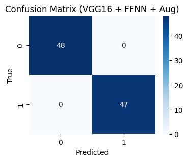

```python
# Build a VGG16 + FFNN model with data augmentation to improve generalization.

# Data augmentation for the training images
augmenter = ImageDataGenerator(
    rotation_range=20,
    width_shift_range=0.1,
    height_shift_range=0.1,
    shear_range=0.1,
    zoom_range=0.1,
    horizontal_flip=True,
    fill_mode='nearest'
)

# No augmentation for validation data
val_gen = ImageDataGenerator()

# Create generators
train_generator = augmenter.flow(X_train_vgg, y_train, batch_size=32, shuffle=True)
val_generator   = val_gen.flow(X_val_vgg, y_val, batch_size=32, shuffle=False)

# Build the model (similar structure to the VGG16 + FFNN model)
vgg_base_aug = VGG16(weights='imagenet', include_top=False, input_shape=X_train_vgg.shape[1:])
for layer in vgg_base_aug.layers:
    layer.trainable = False

model_aug = Sequential([
    vgg_base_aug,
    Flatten(),
    Dense(256, activation='relu'),
    Dropout(0.5),
    Dense(128, activation='relu'),
    Dropout(0.5),
    Dense(1, activation='sigmoid')
])

model_aug.compile(
    optimizer=Adam(learning_rate=1e-4),
    loss='binary_crossentropy',
    metrics=['accuracy']
)

model_aug.summary()

# Train the model using the data augmentation generator
epochs = 20
history_aug = model_aug.fit(
    train_generator,
    epochs=epochs,
    validation_data=val_generator,
    verbose=1
)

# Evaluate on the validation and test sets
val_loss_aug, val_acc_aug = model_aug.evaluate(X_val_vgg, y_val, verbose=0)
test_loss_aug, test_acc_aug = model_aug.evaluate(X_test_vgg, y_test, verbose=0)
print(f'Validation Accuracy (VGG16 + FFNN + Aug): {val_acc_aug:.4f}')
print(f'Test Accuracy (VGG16 + FFNN + Aug): {test_acc_aug:.4f}')

# Predictions and metrics
val_preds_probs_aug = model_aug.predict(X_val_vgg).ravel()
val_preds_aug = (val_preds_probs_aug > 0.5).astype('int32')

print('Classification Report (VGG16 + FFNN + Aug):')
print(classification_report(y_val, val_preds_aug, digits=4))

conf_mat_aug = confusion_matrix(y_val, val_preds_aug)
plt.figure(figsize=(4,3))
sns.heatmap(conf_mat_aug, annot=True, fmt='d', cmap='Blues')
plt.title('Confusion Matrix (VGG16 + FFNN + Aug)')
plt.xlabel('Predicted')
plt.ylabel('True')
plt.show()
```